# NBA Statistics and Salary

Prithvi Tanna

5/29/2020

Every summer, NBA General Managers face tough decisions in regards to players on expiring contracts. They need to decide how much to pay their player. The amount they offer must be an accurate reflection of what the player offers to the team. If a General Manager tries to give a player a lowball offer, the player might decide to take their talents to another team. However, if a General Manager offers too much money, they will have less money to spend on other players. The key is to pay a player what he is truly worth. This project is an attempt to model NBA salaries in 2020 based on player statistics and attributes. I examined many player statistics to find out which ones really matter when deciding to pay a player. Hopefully, my final model can serve as a tool to find out what every player is worth and to find the most overpaid and underpaid players in the NBA.

## Webscraping Data

This section of code involves scraping five different pages on basketball reference and espn for NBA player salary and statistics. Five different datsets were extracted. The first dataset contains the salaries of all NBA players. The second contains every player’s basic counting statistics like points,rebounds, assists, etc. The third dataset contains the more advanced statistics like win shares and value over replacement player. The fourth dataset contains all all star players, which I will use later to identify if a player in the dataset has ever been recognized as an all star. The final dataset is ESPN’s rpm (real plus minus) calculated for every NBA Player.

```r
library(rvest)
library(dplyr)


##scrape salary data
salaries <- html_table(read_html("https://www.basketball-reference.com/contracts/players.html"))[[1]]

colnames(salaries) <- c("Rank","Player","Team","Salary(2019-2020)","Salary(2020-2021)","Salary(2021-2022)","Salary(2022-2023","Salary(2023-2024)","Salary(2024-2025)","Signed Using","Guaranteed")

##Scrape basic statistics
player_stats <- html_table(read_html("https://www.basketball-reference.com/leagues/NBA_2020_per_game.html"), header = TRUE)[[1]]

##scrape advanced statistics
adv_stats <- html_table(read_html("https://www.basketball-reference.com/leagues/NBA_2020_advanced.html"), header = TRUE)[[1]]

#scrape all star data
all_stars = html_table(read_html("https://www.basketball-reference.com/awards/all_star_by_player.html"), header = TRUE)[[1]]

##scrape 1st page of rpm data
rpm = html_table(read_html('http://www.espn.com/nba/statistics/rpm'),header = TRUE)[[1]]

url = 'http://www.espn.com/nba/statistics/rpm/_/page/'

for (i in 2:13){ ##scrape remaining pages of rpm data
   page_name = paste0(url,i)
   df = html_table(read_html(page_name),header = TRUE)[[1]]
   rpm = rbind(rpm,df)
}
```

## Cleaning Functions

The following functions will be used repeatedly throughout the data cleaning process

```r
removeAccents<-function(x)
{
a <- c('À', 'Á', 'Â', 'Ã', 'Ä', 'Å', 'Æ', 'Ç', 'È', 'É', 'Ê', 'Ë', 'Ì', 'Í', 'Î', 'Ï', 'Ð', 'Ñ', 'Ò', 'Ó', 'Ô', 'Õ', 'Ö', 'Ø', 'Ù', 'Ú', 'Û', 'Ü', 'Ý', 'ß', 'à', 'á', 'â', 'ã', 'ä', 'å', 'æ', 'ç', 'è', 'é', 'ê', 'ë', 'ì', 'í', 'î', 'ï', 'ñ', 'ò', 'ó', 'ô', 'õ', 'ö', 'ø', 'ù', 'ú', 'û', 'ü', 'ý', 'ÿ', 'Ā', 'ā', 'Ă', 'ă', 'Ą', 'ą', 'Ć', 'ć', 'Ĉ', 'ĉ', 'Ċ', 'ċ', 'Č', 'č', 'Ď', 'ď', 'Đ', 'đ', 'Ē', 'ē', 'Ĕ', 'ĕ', 'Ė', 'ė', 'Ę', 'ę', 'Ě', 'ě', 'Ĝ', 'ĝ', 'Ğ', 'ğ', 'Ġ', 'ġ', 'Ģ', 'ģ', 'Ĥ', 'ĥ', 'Ħ', 'ħ', 'Ĩ', 'ĩ', 'Ī', 'ī', 'Ĭ', 'ĭ', 'Į', 'į', 'İ', 'ı', 'Ĳ', 'ĳ', 'Ĵ', 'ĵ', 'Ķ', 'ķ', 'Ĺ', 'ĺ', 'Ļ', 'ļ', 'Ľ', 'ľ', 'Ŀ', 'ŀ', 'Ł', 'ł', 'Ń', 'ń', 'Ņ', 'ņ', 'Ň', 'ň', 'ŉ', 'Ō', 'ō', 'Ŏ', 'ŏ', 'Ő', 'ő', 'Œ', 'œ', 'Ŕ', 'ŕ', 'Ŗ', 'ŗ', 'Ř', 'ř', 'Ś', 'ś', 'Ŝ', 'ŝ', 'Ş', 'ş', 'Š', 'š', 'Ţ', 'ţ', 'Ť', 'ť', 'Ŧ', 'ŧ', 'Ũ', 'ũ', 'Ū', 'ū', 'Ŭ', 'ŭ', 'Ů', 'ů', 'Ű', 'ű', 'Ų', 'ų', 'Ŵ', 'ŵ', 'Ŷ', 'ŷ', 'Ÿ', 'Ź', 'ź', 'Ż', 'ż', 'Ž', 'ž', 'ſ', 'ƒ', 'Ơ', 'ơ', 'Ư', 'ư', 'Ǎ', 'ǎ', 'Ǐ', 'ǐ', 'Ǒ', 'ǒ', 'Ǔ', 'ǔ', 'Ǖ', 'ǖ', 'Ǘ', 'ǘ', 'Ǚ', 'ǚ', 'Ǜ', 'ǜ', 'Ǻ', 'ǻ', 'Ǽ', 'ǽ', 'Ǿ', 'ǿ');
b <- c('A', 'A', 'A', 'A', 'A', 'A', 'AE', 'C', 'E', 'E', 'E', 'E', 'I', 'I', 'I', 'I', 'D', 'N', 'O', 'O', 'O', 'O', 'O', 'O', 'U', 'U', 'U', 'U', 'Y', 's', 'a', 'a', 'a', 'a', 'a', 'a', 'ae', 'c', 'e', 'e', 'e', 'e', 'i', 'i', 'i', 'i', 'n', 'o', 'o', 'o', 'o', 'o', 'o', 'u', 'u', 'u', 'u', 'y', 'y', 'A', 'a', 'A', 'a', 'A', 'a', 'C', 'c', 'C', 'c', 'C', 'c', 'C', 'c', 'D', 'd', 'D', 'd', 'E', 'e', 'E', 'e', 'E', 'e', 'E', 'e', 'E', 'e', 'G', 'g', 'G', 'g', 'G', 'g', 'G', 'g', 'H', 'h', 'H', 'h', 'I', 'i', 'I', 'i', 'I', 'i', 'I', 'i', 'I', 'i', 'IJ', 'ij', 'J', 'j', 'K', 'k', 'L', 'l', 'L', 'l', 'L', 'l', 'L', 'l', 'l', 'l', 'N', 'n', 'N', 'n', 'N', 'n', 'n', 'O', 'o', 'O', 'o', 'O', 'o', 'OE', 'oe', 'R', 'r', 'R', 'r', 'R', 'r', 'S', 's', 'S', 's', 'S', 's', 'S', 's', 'T', 't', 'T', 't', 'T', 't', 'U', 'u', 'U', 'u', 'U', 'u', 'U', 'u', 'U', 'u', 'U', 'u', 'W', 'w', 'Y', 'y', 'Y', 'Z', 'z', 'Z', 'z', 'Z', 'z', 's', 'f', 'O', 'o', 'U', 'u', 'A', 'a', 'I', 'i', 'O', 'o', 'U', 'u', 'U', 'u', 'U', 'u', 'U', 'u', 'U', 'u', 'A', 'a', 'AE', 'ae', 'O', 'o');

for(i in 1:length(a))
{
x<-gsub(x = x,pattern = a[i],replacement = b[i])
}
return(x)
}

removeTitles <- function(x){
  x = gsub(" Jr.","",x,fixed = TRUE)
  x = gsub(" Sr.","",x,fixed = TRUE)
  x = gsub(" IV","",x,fixed = TRUE)
  x = gsub(" III","",x,fixed = TRUE)
  x = gsub(" II","",x,fixed = TRUE)
  x = gsub(".","",x,fixed = TRUE)
  return(x)
}
```

## Cleaning and Combining Data

In this section, we cleaned and combined our datasets. Some common issues were empty rows of data, different names for the same player in data frames (Jr. or III), and players playing a season for multiple teams meaning they have more than one entry in the dataframe. Sometimes, a player playing for multiple teams in one season would have different salaries for different teams. I solved this problem by adding up total salalries for players who players for more than one team. I also had to remove all foreign accents as the RPM dataset did not include them. The RPM dataset also had the name column in the format (name,pos) so I had to extract only the name from this column. Once all the names matched up, I used an inner join command to combine all the datasets by player name. There were also many NA values in the dataset. When examining the source of these NA values, I realized that they were coming from players who did not play much. For example, if a player has not shot any free throws the free throw percentage of that player will come up as NA.I addressed this by replacing NA values with zero, since the players with NA values do not play much.

```r
library(stringi)

##filter out empty rows and incorrect rows
salaries_cleaned <- salaries %>%
  filter(Player != "Player" & Player != "")

salaries_cleaned = salaries_cleaned[,-c(5:9)] ##filter out variables we are not interested in

##clean salary column to prepare for numeric conversion
salaries_cleaned$`Salary(2019-2020)` = gsub("$","",salaries_cleaned$`Salary(2019-2020)`,fixed = TRUE)
salaries_cleaned$`Salary(2019-2020)` = gsub(",","",salaries_cleaned$`Salary(2019-2020)`,fixed = TRUE)
salaries_cleaned$Guaranteed =  gsub("$","",salaries_cleaned$Guaranteed,fixed = TRUE)
salaries_cleaned$Guaranteed = gsub(",","",salaries_cleaned$Guaranteed,fixed = TRUE)

##Fill in empty rows in "signed using"
salaries_cleaned$`Signed Using` = replace(salaries_cleaned$`Signed Using`, salaries_cleaned$`Signed Using` == "", "Other")

salaries_cleaned$`Salary(2019-2020)` = as.numeric(salaries_cleaned$`Salary(2019-2020)`)
salaries_cleaned$Guaranteed = as.numeric(salaries_cleaned$Guaranteed)

##Adding salaries for players who were on multiple teams
salaries_cleaned_2 <- aggregate(`Salary(2019-2020)` ~ Player, data = salaries_cleaned, sum)
salaries_cleaned_3 <- aggregate(Guaranteed ~ Player, data = salaries_cleaned, sum)

salaries_cleaned = salaries_cleaned[!duplicated(salaries_cleaned$Player),] %>%
  select(-`Salary(2019-2020)`,-Guaranteed)

##Adding combined salaries to dataset using an inner join
salaries_cleaned = salaries_cleaned %>%
  inner_join(salaries_cleaned_2) %>%
  inner_join(salaries_cleaned_3)

salaries_cleaned$Player[which(salaries_cleaned$Player == "Mohamed Bamba",arr.ind = TRUE)] = "Mo Bamba"

salaries_cleaned$Player[which(salaries_cleaned$Player == "Taurean Waller-Prince",arr.ind = TRUE)] = "Taurean Prince"

salaries_cleaned$Player = removeTitles(salaries_cleaned$Player) ##Removing Jr.,Sr. etc from names

salaries_cleaned$`Salary(2019-2020)` = salaries_cleaned$`Salary(2019-2020)`/1000000

salaries_cleaned$Guaranteed = salaries_cleaned$Guaranteed/1000000

salaries_cleaned = salaries_cleaned[,-c(1,3)]

duplicate_players <- player_stats %>%
  count(Player) %>%
  filter(n > 1)

player_stats_cleaned <- player_stats %>%
  filter(Tm == "TOT" | !(Player %in% duplicate_players$Player)) ##Filtering out players who appear more than once

num_transform <- player_stats_cleaned %>%
  select(-Rk,-Player,-Pos,-Tm)

for(i in colnames(num_transform)){ ##char to numeric
  player_stats_cleaned[[i]] = as.numeric(player_stats_cleaned[[i]])
}

player_stats_cleaned$Pos = gsub("\\-.*","",player_stats_cleaned$Pos) ##Eliminating second position for players

player_stats_cleaned$Pos = gsub("^G$","SG",player_stats_cleaned$Pos)


player_stats_cleaned$Player = removeTitles(player_stats_cleaned$Player)##Removing Jr.,Sr. etc from names

adv_stats_cleaned = adv_stats[,-c(1,3:4,6:7,20,25)]

duplicate_players_2 <- adv_stats_cleaned %>%
  count(Player) %>%
  filter(n > 1)

adv_stats_cleaned <- adv_stats_cleaned %>% ##Filtering out players who appear more than once
  filter(Tm == "TOT" | !(Player %in% duplicate_players_2$Player))

num_transform_2 <- adv_stats_cleaned %>%
  select(-Player,-Tm)

for(i in colnames(num_transform_2)){
  adv_stats_cleaned[[i]] = as.numeric(adv_stats_cleaned[[i]])
}

adv_stats_cleaned = adv_stats_cleaned[,-2]

adv_stats_cleaned$Player = removeTitles(adv_stats_cleaned$Player)

Player = c()

for (i in 1:length(rpm$NAME)){ ##Extracting the name of players from column with format (name, position)
Player = c(Player,strsplit(rpm$NAME,split = ',')[[i]][1])
}

rpm$Player = Player

rpm = rpm %>%
  select(Player,ORPM,DRPM,RPM,WINS)

rpm$Player[which(rpm$Player == "Wes Iwundu",arr.ind = TRUE)] = "Wesley Iwundu"

rpm$Player = removeTitles(rpm$Player)

salaries_stats = player_stats_cleaned %>%
  inner_join(salaries_cleaned) %>%
  inner_join(adv_stats_cleaned)


salaries_stats$Player = removeAccents(salaries_stats$Player) ##Removing foreign accents for international players

salaries_stats = salaries_stats %>%
  inner_join(rpm)

salaries_stats$Pos = as.factor(salaries_stats$Pos)

salaries_stats[is.na(salaries_stats)] = 0 ##Replacing NA with 0

print(as_tibble(head(salaries_stats))) ##Final Cleaned Dataset
```

```
## # A tibble: 6 x 57
##   Rk    Player Pos     Age Tm        G    GS    MP    FG   FGA `FG%`  `3P` `3PA`
##   <chr> <chr>  <fct> <dbl> <chr> <dbl> <dbl> <dbl> <dbl> <dbl> <dbl> <dbl> <dbl>
## 1 1     Steve… C        26 OKC      62    62  27     4.6   7.7 0.595   0     0
## 2 2     Bam A… PF       22 MIA      72    72  33.6   6.1  11   0.557   0     0.2
## 3 3     LaMar… C        34 SAS      53    53  33.1   7.4  15   0.493   1.2   3
## 4 5     Nicke… SG       21 NOP      46     0  12.1   1.9   5.4 0.351   1     2.8
## 5 6     Grays… SG       24 MEM      37     0  18.7   3.1   6.6 0.461   1.5   3.8
## 6 7     Jarre… C        21 BRK      69    63  26.3   4.3   6.6 0.65    0     0.1
## # … with 44 more variables: `3P%` <dbl>, `2P` <dbl>, `2PA` <dbl>, `2P%` <dbl>,
## #   `eFG%` <dbl>, FT <dbl>, FTA <dbl>, `FT%` <dbl>, ORB <dbl>, DRB <dbl>,
## #   TRB <dbl>, AST <dbl>, STL <dbl>, BLK <dbl>, TOV <dbl>, PF <dbl>, PTS <dbl>,
## #   `Signed Using` <chr>, `Salary(2019-2020)` <dbl>, Guaranteed <dbl>,
## #   PER <dbl>, `TS%` <dbl>, `3PAr` <dbl>, FTr <dbl>, `ORB%` <dbl>,
## #   `DRB%` <dbl>, `TRB%` <dbl>, `AST%` <dbl>, `STL%` <dbl>, `BLK%` <dbl>,
## #   `TOV%` <dbl>, `USG%` <dbl>, OWS <dbl>, DWS <dbl>, WS <dbl>, `WS/48` <dbl>,
## #   OBPM <dbl>, DBPM <dbl>, BPM <dbl>, VORP <dbl>, ORPM <dbl>, DRPM <dbl>,
## #   RPM <dbl>, WINS <dbl>
```

## Adding Features

The first feature I created was called age_cat, where I categorized the age variable. The first category I created was young. These are players who are still on their first or second contracts. The second category I created was prime, which is when a player is playing his best basketball and is most likely making the most money in his career. The last category is old. These players are past their primes and are likely making less than they used to. There are obviously exceptions to this as players like LeBron James have been able to maintain their level of play into older ages. The second feature I added was all star, which labeled whether a player has recently been an all star. I had to manually filter out players who were former all stars but are no longer playing up tot hat level today (e.g Dwight Howard, Derrick Rose). The final feature I added on was starter. I created this by dividing the number of games started vs the number of games played. If this ratio was greater than 0.9, I labeled that player a starter.

```r
salaries_stats <- salaries_stats %>% ##Splitting age
mutate(Age_cat = cut(Age, breaks = c(-Inf,26,34,Inf),
                       labels = c("Young","Prime","Old")))

all_stars$Player = removeAccents(all_stars$Player)

all_stars$Player = removeTitles(all_stars$Player)

all_stars = all_stars %>%
  filter(Player != "Carmelo Anthony" & Player != "Isaiah Thomas" & Player != "Rajon Rondo" & Player != "Derrick Rose" & Player != "Vince Carter" & Player != "Dwight Howard" & Player != "Tyson Chandler" & Player != "DeAndre Jordan" & Player != "Glenn Robinson" & Player != "Tim Hardaway" & Player != "Larry Nance" & Player != "Jeff Teague" & Player != "Andre Iguodola" & Player != "Kyle Korver" & Player != "Brook Lopez" & Player != "Gary Payton")

salaries_stats <- salaries_stats %>%
  mutate(Starter = as.factor(if_else(GS/G > 0.9,"Yes","No")),
         G_f = as.factor(if_else(Pos == "PG"|Pos == "SG","Guard","Forward")),
         All_Star = salaries_stats$Player %in% all_stars$Player)
```

## Visualization

This section involves basic exploratory data analysis by examining the distribution of variables and their relationships with each other. We are particulary interested in the relationship between salary and each basic and advanced statistic.

## Correlation Heatmap

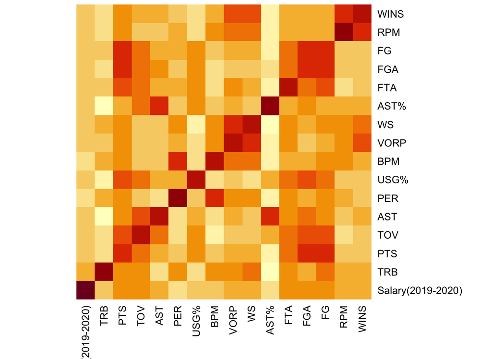

## Basic Stats Pairplot

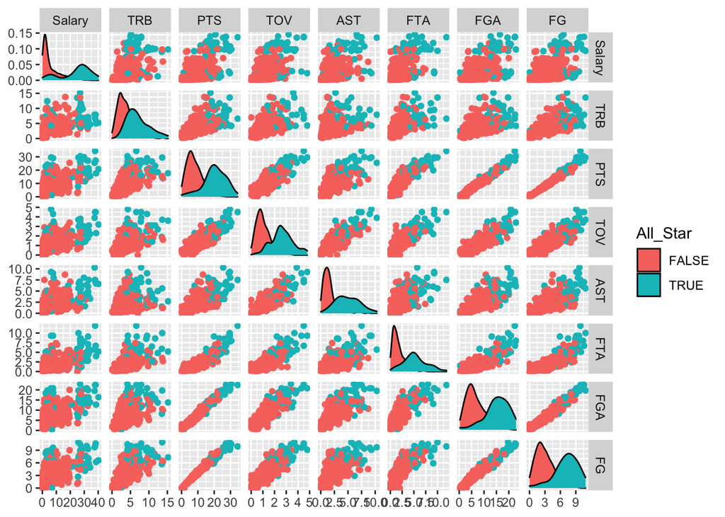

```r
library(GGally)

salaries_stats %>%
  ggpairs(legend = 1,
          columns = c(32,24,30,28,25,20,10,9),
          upper = list(continuous = "points", combo = "dot_no_facet"),
          ggplot2::aes(colour=All_Star),
          columnLabels = c("Salary","TRB", "PTS", "TOV" ,"AST","FTA","FGA","FG")
          )
```

## Advanced Stats Pairplot

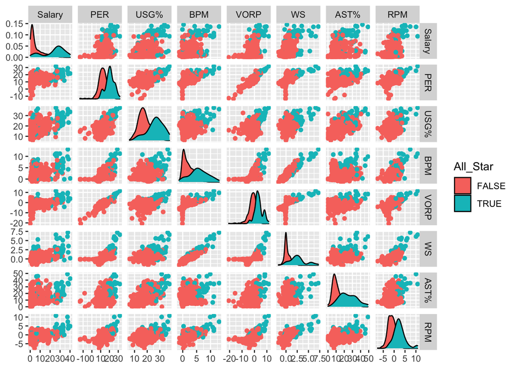

```r
salaries_stats %>%
  ggpairs(legend = 1,
          columns = c(32,34,45,48,52,53,41,56),
          upper = list(continuous = "points", combo = "dot_no_facet"),
          ggplot2::aes(colour= All_Star),
          columnLabels = c("Salary","PER", "USG%", "BPM" ,"VORP","WS","AST%","RPM"))
```

## Position

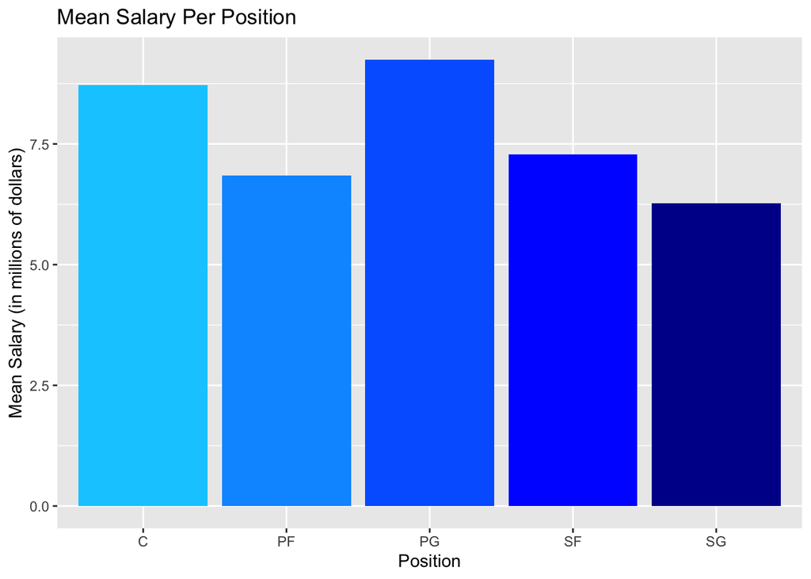

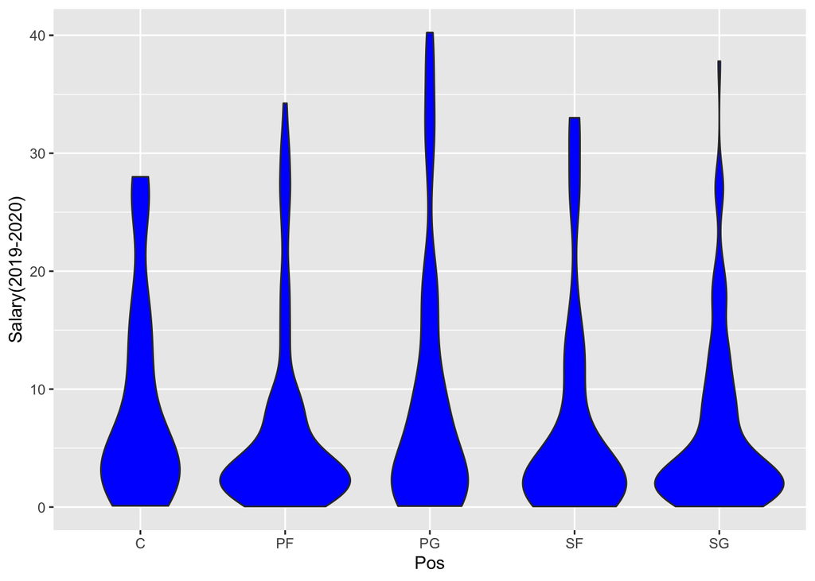

### Age Categories

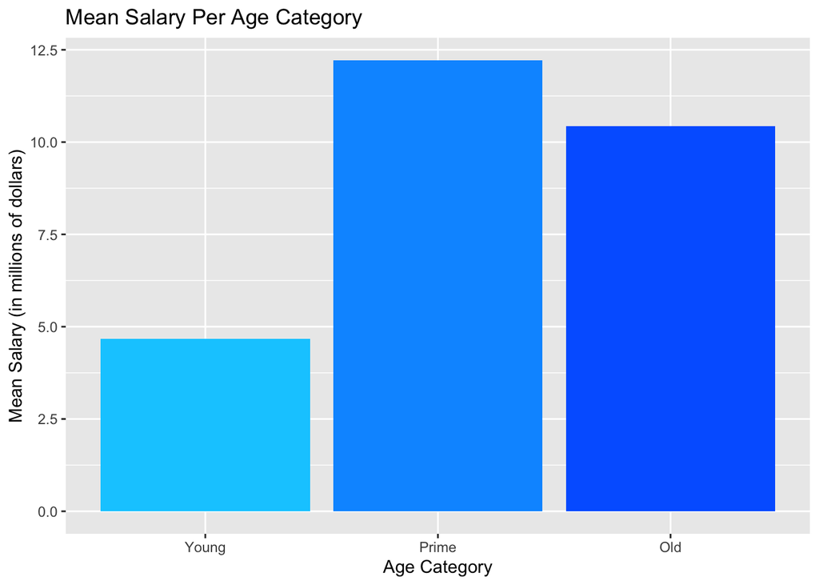

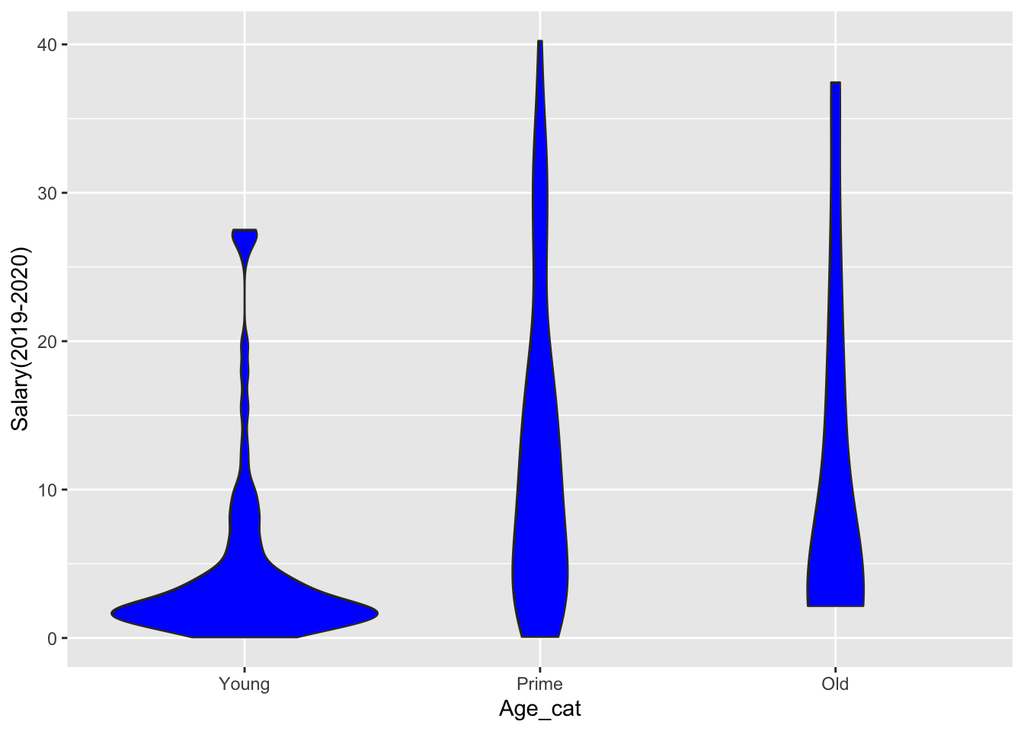

## Starter

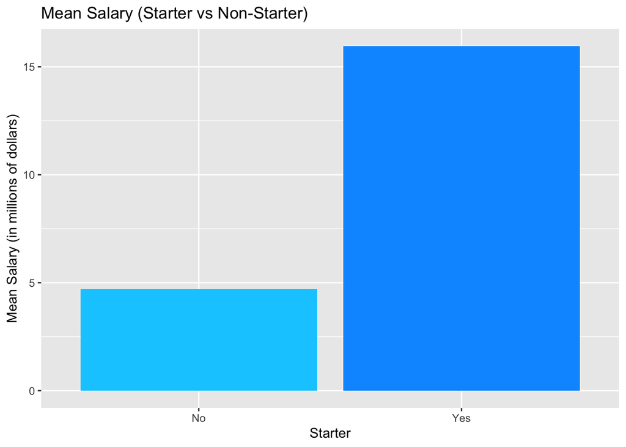

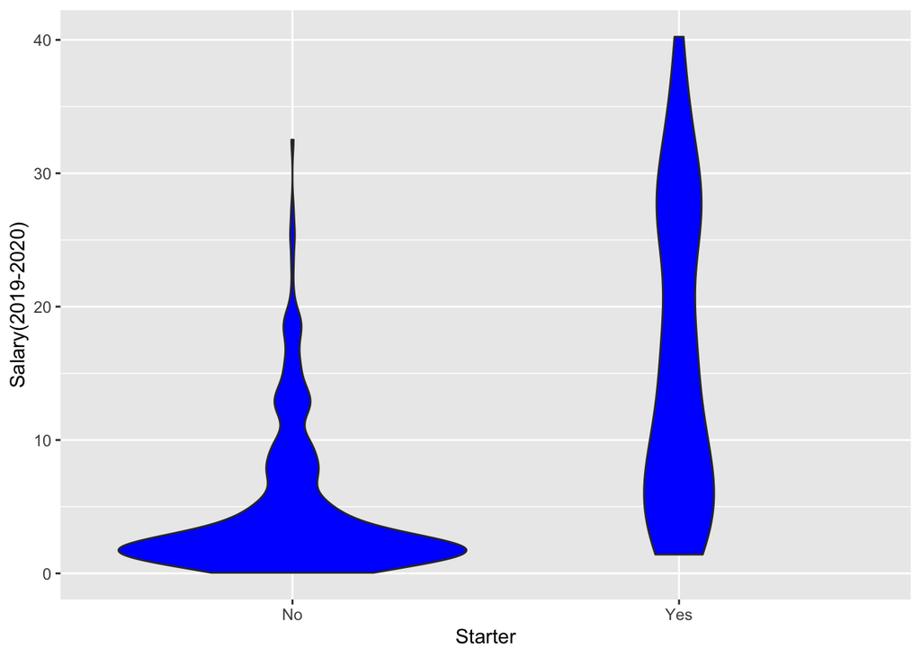

## All_Star

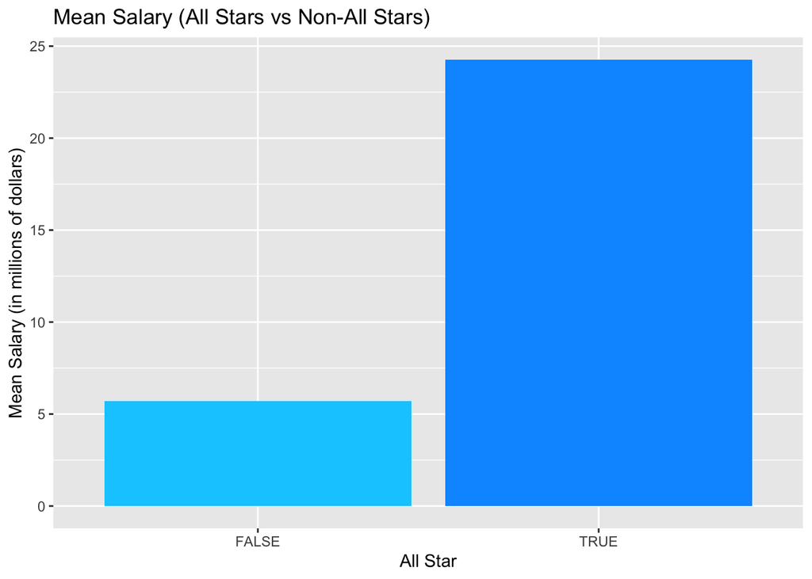

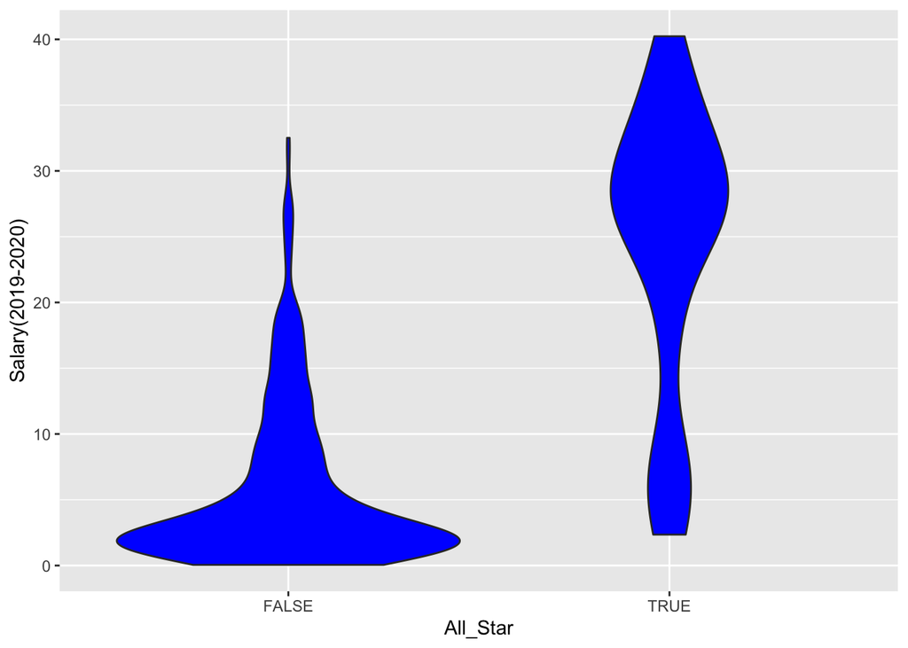

As one would assume, there is a clear distinction between all star and non all star players in many of the statistics. When looking at the pairplots, we can clearly see two seperate groupings forming for most of the variables. Additionally,the histograms for most of our variables are right skewed for non all star players while more centrally focused for all star players. When looking at the age groupings of players, most young players are making less than 10 million dollars and players in their prime are making the most money. If an NBA team can get production from young players, they would be saving a lot of money in the short term. The gulf in pay between starters and non starters is also significant, but it is not as much as the gulf in pay between all stars and non all stars.

## Modeling

This section involves modeling with many of the statistics we scraped and features we added. The first model I tried to fit salary to was multiple linear regression. The second model I tried was ridge regression. I chose my features by carefully examining the correlation heatmap and scatterplots to get an idea of the variables that were correlated with salary.

```r
set.seed(70000,sample.kind="Rounding" )

training = sample_frac(salaries_stats,(0.75)) #training dataset

testing = salaries_stats %>%
    filter(!(Player %in% training$Player)) #testing dataset

salary_model = lm(`Salary(2019-2020)` ~  TRB + PTS + FTA   + TOV + AST + PER + RPM + `USG%` + VORP  + WS  + Age_cat + Starter + All_Star, data = training)

summary(salary_model)
```

```
##
## Call:
## lm(formula = `Salary(2019-2020)` ~ TRB + PTS + FTA + TOV + AST +
##     PER + RPM + `USG%` + VORP + WS + Age_cat + Starter + All_Star,
##     data = training)
##
## Residuals:
##      Min       1Q   Median       3Q      Max
## -19.3205  -2.7296  -0.1926   2.0046  21.5388
##
## Coefficients:
##              Estimate Std. Error t value Pr(>|t|)
## (Intercept)   0.22196    1.78841   0.124  0.90130
## TRB           0.55088    0.21199   2.599  0.00977 **
## PTS           0.33793    0.14758   2.290  0.02264 *
## FTA           0.67892    0.40882   1.661  0.09770 .
## TOV          -1.44903    1.18237  -1.226  0.22122
## AST           0.32763    0.37345   0.877  0.38095
## PER          -0.08332    0.08994  -0.926  0.35489
## RPM           0.42181    0.22157   1.904  0.05780 .
## `USG%`        0.03402    0.11060   0.308  0.75861
## VORP          0.66639    0.80276   0.830  0.40705
## WS           -0.81903    0.41171  -1.989  0.04747 *
## Age_catPrime  6.09943    0.63428   9.616  < 2e-16 ***
## Age_catOld    3.65116    1.80701   2.021  0.04411 *
## Starter       3.07542    0.96566   3.185  0.00158 **
## All_Star      8.37322    1.41068   5.936 7.22e-09 ***
## ---
## Signif. codes:  0 '***' 0.001 '**' 0.01 '*' 0.05 '.' 0.1 ' ' 1
##
## Residual standard error: 5.441 on 340 degrees of freedom
## Multiple R-squared:  0.6538, Adjusted R-squared:  0.6396
## F-statistic: 45.87 on 14 and 340 DF,  p-value: < 2.2e-16
```

Our model yields a $R^2$ of 0.6538. This means that 65.38 percent of variation in the model is due to the linear relationship between player salary and our predictors. The adjusted $R^2$ is 0.6396, or the $R^2$ adjusted for the number of predictors.

## Checking Model Accuracy

We want to see how accurately our model can predict a player’s salary. To do this, we randomly split the dataset into a training and testing dataset. The model was trained on the training datset (3/4 of total data). We use the testing dataset to check how well the model can perform on data that it has not been trained on. The graph below gives a visual representation of the models salary prediction on the testing dataset. I also calculated the out of sample RMSE, which shows the deviance of our predictions on the testing data from the actual salary amount.

```r
prediction_data = data.frame(player = testing$Player,Actual = testing$`Salary(2019-2020)`,Predicted = predict(salary_model,newdata = testing))

prediction_data$player = as.character(prediction_data$player)

for(i in 1:length(prediction_data$Predicted)){ ##Forces salary prediction to be above 0
  if(prediction_data$Predicted[i] < 0.05){
    prediction_data$Predicted[i] = 0.05
  }
}

RMSE = function(m, o){
  sqrt(mean((m - o)^2))
}


RMSE(prediction_data$Predicted,prediction_data$Actual)
```

```
## [1] 4.95146
```

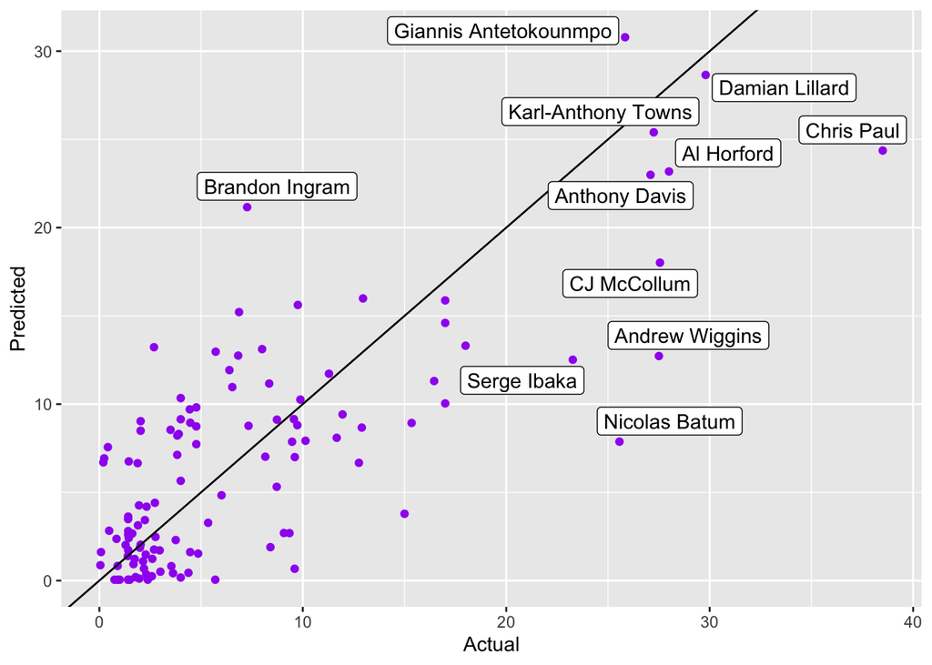

```r
ggplot(prediction_data, aes(x = Actual, y = Predicted)) +
  geom_point(color = "purple") +
  geom_abline(intercept = 0, slope = 1) +
  geom_label_repel(aes(label= ifelse(Predicted > 20 | Actual > 20 ,player,"")))
```

## Ridge Regression

We can also try ridge regression to see if it yields a better RMSE score than linear regression on the same train test split. Ridge regression allows for more bias and less variance by adding a penalty term when minimizing our residuals squared $\lambda(\beta_1^2 + \beta_2^2 + ... \beta_p^2)$. We pick this penalty term (lambda) through cross validation where we select the lambda that minimizes the cross validation error(MSE). This is demonstrated in the graph below that shows the optimal range of log(lambda) that minimizes MSE.

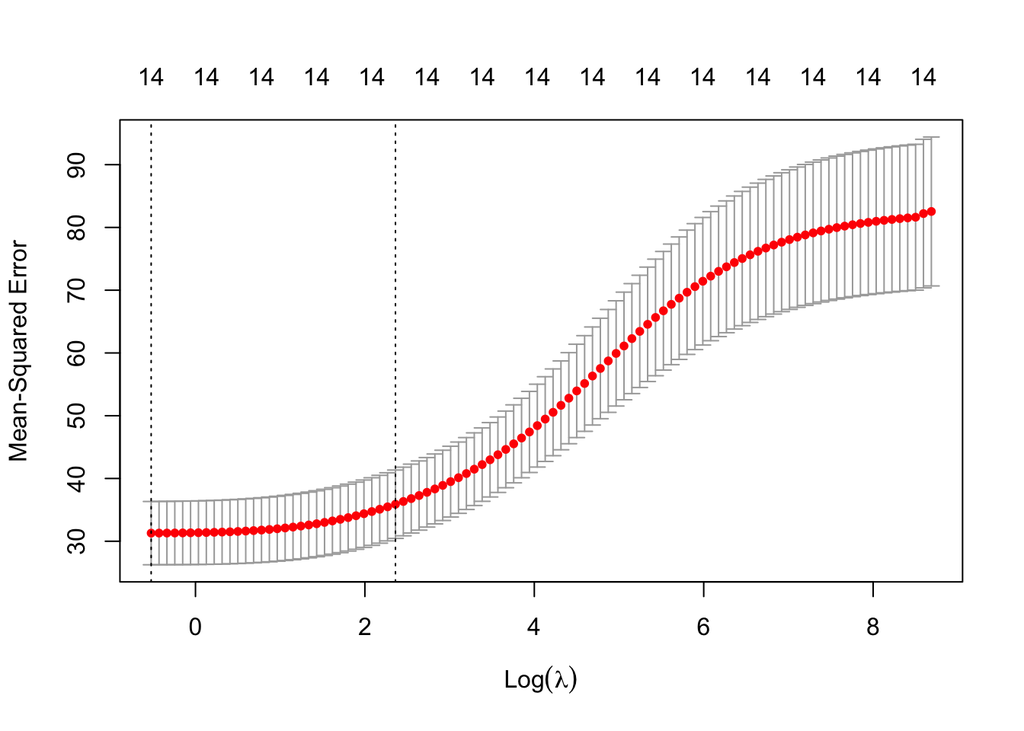

```r
library(glmnet)
Xmat <- as.matrix(training %>%
                    select(TRB,PTS,FTA,TOV,AST,PER,RPM,`USG%`,VORP ,WS,Prime,Old,Starter,All_Star))
Ymat <- training$`Salary(2019-2020)`
nba.ridge <- glmnet(Xmat, Ymat, alpha=0)

set.seed(20000)

# Ridge regression, choosing lambda by cross-validation
nba.ridge.cv <- cv.glmnet(Xmat, Ymat, alpha=0, nfold=5)
plot(nba.ridge.cv)
```

```r
prediction_data_ridge = data.frame(player = testing$Player,Actual = testing$`Salary(2019-2020)`,Predicted = predict(nba.ridge.cv, newx = as.matrix(testing %>%
                    select(TRB,PTS,FTA,TOV,AST,PER,RPM,`USG%`,VORP,WS,Prime,Old,Starter,All_Star)), s = "lambda.min")
)

prediction_data_ridge$Predicted = prediction_data_ridge$X1
for(i in 1:length(prediction_data_ridge$Predicted)){ ##Forces salary prediction to be above 0
  if(prediction_data_ridge$Predicted[i] < 0.05){
    prediction_data_ridge$Predicted[i] = 0.05
  }
}
prediction_data_ridge$player = as.character(prediction_data_ridge$player)


RMSE(prediction_data_ridge$Predicted,testing$`Salary(2019-2020)`)
```

```
## [1] 4.908384
```

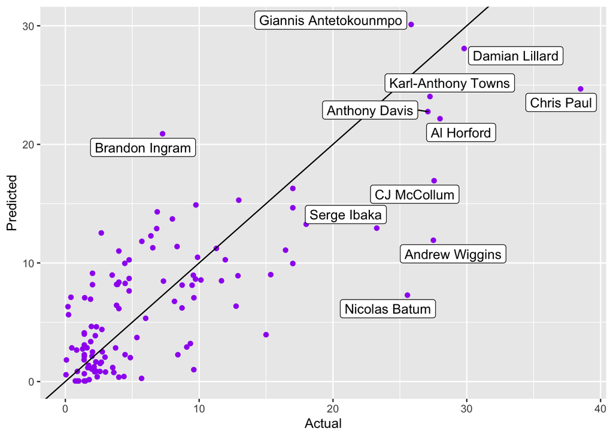

```r
ggplot(prediction_data_ridge, aes(x = Actual, y = Predicted)) +
  geom_point(color = "purple") +
  geom_abline(intercept = 0, slope = 1) +
  geom_label_repel(aes(label= ifelse(Predicted > 20 | Actual > 20 ,player,"")))
```

## Conclusion/Final Thoughts

After calculating the RMSE on our testing data for both regression methods, ridge regression seems to perform slightly better. Overall, our predictions deviate from actual salaries by about 4.9 million dollars. This is not terrible, but it could definitely be better. If I were an NBA GM, I would use a model like this as one factor in determining what a player is truly worth. Many times, a GM may have to pay more than the market value of a player in order to convince the player to stay. This is why a player like Andrew Wiggins makes as much as he does despite zero all star appearances. The model also seems to point out when players like Brandon Ingram are outplaying their contracts.